# Applying Regular Expressions, Generalized Horizons and Quantiles

## `generalize.hz()`

[`aqp::generalize.hz()`](http://ncss-tech.github.io/aqp/docs/reference/generalize.hz.html) is a tool in the `aqp` **R** package that simplifies grouping horizon data when you have a `character` attribute that can be “matched” partially or completely to assign groups. This tends to have the effect of “generalizing” the number of groups relative to the input. The function takes a character vector of inputs, a character vector of patterns, and a character vector of replacement names as arguments. See [`?aqp::generalize.hz`](http://ncss-tech.github.io/aqp/docs/reference/generalize.hz.html) for details.

`generalize.hz()` uses a special text-matching string type called “[regular expressions](http://regular-expressions.info/)” or REGEX for the pattern argument. Regular expressions are found commonly in the **R** ecosystem and in computer science in general for automating and generalizing text-processing tasks. In the following example we will build very simple REGEX patterns based on some soil profile data.

## `jacobs2000`

```r
library(aqp, warn.conflicts = FALSE)
data("jacobs2000", package="aqp")
jacobs2000 <- jacobs2000 # use your own data here, replace jacobs2000 with your object
```

`jacobs2000` is a data set in `aqp` that is stored as a `SoilProfileCollection`. It contains select soil morphologic data from “Redoximorphic Features as Indicators of Seasonal Saturation, Lowndes County, Georgia”. The examples in this document depend on one another sequentially, so run them in order.

**Reference** Jacobs, P. M., L. T. West, and J. N. Shaw. 2002. Redoximorphic Features as Indicators of Seasonal Saturation, Lowndes County, Georgia. Soil Sci. Soc. Am. J. 66:315-323. [doi:10.2136/sssaj2002.3150](https://acsess.onlinelibrary.wiley.com/doi/abs/10.2136/sssaj2002.3150)

```r
# all horizon designations
sort(table(jacobs2000$name))
```

```
##
##     A   B'h   B/C   Bh1   Bh2  Btv1  Btv2  Btv3 Btvg1 Btvg2    C1    C2    C3
##     1     1     1     1     1     1     1     1     1     1     1     1     1
##   Cg1   Cg2   E'1   E'2    2C    AE    Bt   Btc Btcv1 Btcv2    E1    E2     C
##     1     1     1     1     2     2     2     2     2     2     2     2     3
##     E    Ap
##     4     6
```

## Master Horizon Designations

- Using REGEX [capture groups](https://www.regular-expressions.info/refcapture.html)

### All

```r
# copy next line to re-use in your code
getMasterHorizonDesignations <- function(name) gsub("[\\^2-9]*([A-Z\\/]+).*", "\\1", name)
```

**Example:**

```r
jacobs2000$g1 <- getMasterHorizonDesignations(jacobs2000$name)

sort(table(jacobs2000$g1))
```

```
##
## B/C  AE   A   C   E   B
##   1   2   7  10  10  16
```

### *Primary* Horizon Designation

- Get the first capital letter – for combination (`B/C` = `B`) or transition horizons (`AE` = `A`)

```r
# copy next line to re-use in your code
getPrimaryMasterHorizonDesignation <- function(name) gsub("[\\^2-9]*([A-Z]).*", "\\1", name)
```

**Example:**

```r
jacobs2000$g2 <- getPrimaryMasterHorizonDesignation(jacobs2000$name)

# save the names
g2_names <- names(table(jacobs2000$g2))

sort(table(jacobs2000$g2))
```

```
##
##  A  C  E  B
##  9 10 10 17
```

## Horizon *suffixes*

- Using replacement of *non*-target characters.

```r
# copy next line to re-use in your code
getHorizonSuffixes <- function(name) gsub("[\\^1-9A-Z\\/']+", "", name)
```

**Example:**

```r
jacobs2000$g3 <- getHorizonSuffixes(jacobs2000$name)
sort(table(jacobs2000$g3))
```

```
##
##   g   t  tc tvg   h  tv tcv   p
##   2   2   2   2   3   3   4   6  22
```

## Calculate Generalized Horizon

- Using master horizon designations as search terms and patterns
- `aqp::generalize.hz()` with the *primary* designation in `g2_names` (calculated above)

**Example:**

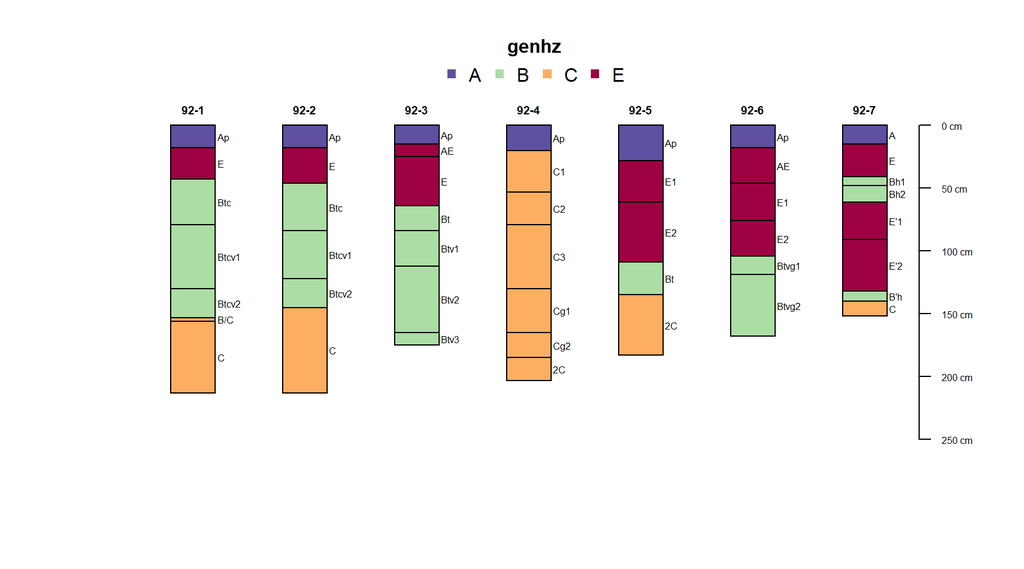

```r
jacobs2000$genhz <- generalize.hz(jacobs2000$name, new = g2_names, pat = g2_names)

plot(jacobs2000, color="genhz")
```

```r
aggregate(jacobs2000[['clay']], by = list(genhz = jacobs2000$genhz), quantile, na.rm = TRUE)
```

```
##   genhz  x.0% x.25% x.50% x.75% x.100%
## 1     A  0.00  2.50  3.00  5.00   7.00
## 2     B  3.00 11.50 21.00 34.50  51.00
## 3     C  0.00  2.25  3.00 32.25  50.00
## 4     E  0.00  1.75  2.00  6.00  15.00
```

## Follow along with your own data

If you are following with your own data, not `jacobs2000`, you may need to adjust the following patterns for horizons that occur in your data set.

### Get more detailed (1)

Add `Bh` group to names and patterns.

```r
# add Bh group
g2_names_2 <- c(g2_names, "Bh")
g2_pat_2 <- c(g2_names, "B[h']+")
```

Calculate a more specific `genhz` group (call it `genhz2`)

```r
jacobs2000$genhz2 <- generalize.hz(jacobs2000$name, new = g2_names_2, pat = g2_pat_2)
```

Inspect.

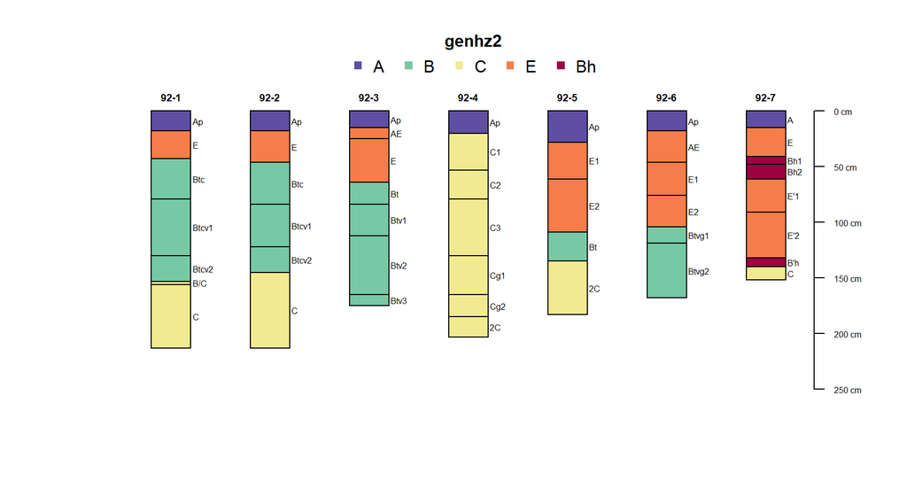

```r
plot(jacobs2000, color="genhz2")
```

```r
aggregate(jacobs2000[['clay']], by = list(genhz2 = jacobs2000$genhz2), quantile, na.rm = TRUE)
```

```
##   genhz2  x.0% x.25% x.50% x.75% x.100%
## 1      A  0.00  2.50  3.00  5.00   7.00
## 2      B  7.00 18.00 30.00 36.00  51.00
## 3      C  0.00  2.25  3.00 32.25  50.00
## 4      E  0.00  1.75  2.00  6.00  15.00
## 5     Bh  3.00  3.00  3.00  3.50   4.00
```

### Get more detailed (2)

Add `g` group to names and patterns.

```r
g2_names_3 <- c(g2_names_2, "g")
g2_pat_3 <- c(g2_pat_2, "g")
```

Calculate a *more* specific `genhz` group (call it `genhz3`)

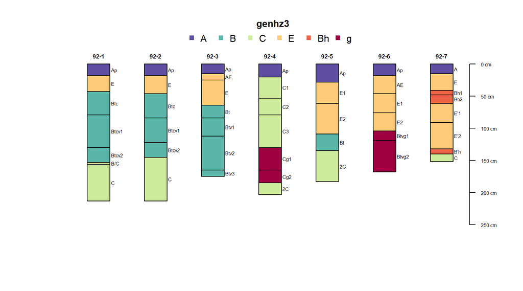

```r
jacobs2000$genhz3 <- generalize.hz(jacobs2000$name, new = g2_names_3, pat = g2_pat_3)

plot(jacobs2000, color="genhz3")
```

```r
aggregate(jacobs2000[['clay']], by = list(genhz3 = jacobs2000$genhz3), quantile, na.rm = TRUE)
```

```
##   genhz3  x.0% x.25% x.50% x.75% x.100%
## 1      A  0.00  2.50  3.00  5.00   7.00
## 2      B  7.00 18.50 32.00 37.50  51.00
## 3      C  2.00  3.00  6.00 41.75  50.00
## 4      E  0.00  1.75  2.00  6.00  15.00
## 5     Bh  3.00  3.00  3.00  3.50   4.00
## 6      g  0.00  0.75  9.50 21.00  30.00
```

### Get more detailed (3)

Add `v` group to names and patterns.

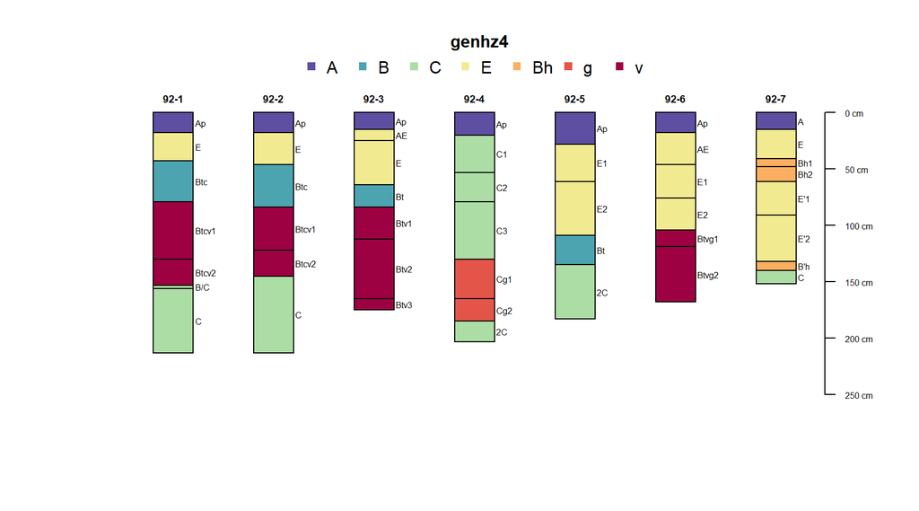

```r
# add v group
g2_names_4 <- c(g2_names_3, "v")
g2_pat_4 <- c(g2_pat_3, "v")

# calculate a _more_ specific genhz group
jacobs2000$genhz4 <- generalize.hz(jacobs2000$name, new = g2_names_4, pat = g2_pat_4)

plot(jacobs2000, color = "genhz4")
```

# Calculate Thickness

For sub-horizons in each class.

```r
jacobs2000$thickness <-  jacobs2000$bottom - jacobs2000$top

# thickness of individual horizons, by group
hbygrp <- aggregate(jacobs2000$thickness, by = list(genhz4 = jacobs2000$genhz4), quantile)
hbygrp
```

```
##   genhz4  x.0% x.25% x.50% x.75% x.100%
## 1      A 15.00 16.50 18.00 19.00  28.00
## 2      B 20.00 24.50 31.00 36.50  38.00
## 3      C  3.00 18.00 33.00 51.00  68.00
## 4      E 10.00 27.50 29.00 34.50  48.00
## 5     Bh  7.00  7.50  8.00 10.50  13.00
## 6      g 20.00 23.75 27.50 31.25  35.00
## 7      v 10.00 23.00 28.00 49.00  53.00
```

# Total Thickness by Profile

Total thickness of each class (may not be contiguous) per profile.

```r
thbyprof <- profileApply(jacobs2000, function(p) {
    data.frame(id = profile_id(p), aggregate(p$thickness, by = list(genhz4 = p$genhz4), sum))
  }, simplify = FALSE)

# inspect "unsimplified" result
thbyprof
```

```
## $`92-1`
##     id genhz4  x
## 1 92-1      A 18
## 2 92-1      B 36
## 3 92-1      C 60
## 4 92-1      E 25
## 5 92-1      v 74
##
## $`92-2`
##     id genhz4  x
## 1 92-2      A 18
## 2 92-2      B 38
## 3 92-2      C 68
## 4 92-2      E 28
## 5 92-2      v 61
##
## $`92-3`
##     id genhz4  x
## 1 92-3      A 15
## 2 92-3      B 20
## 3 92-3      E 49
## 4 92-3      v 91
##
## $`92-4`
##     id genhz4   x
## 1 92-4      A  20
## 2 92-4      C 128
## 3 92-4      g  55
##
## $`92-5`
##     id genhz4  x
## 1 92-5      A 28
## 2 92-5      B 26
## 3 92-5      C 48
## 4 92-5      E 81
##
## $`92-6`
##     id genhz4  x
## 1 92-6      A 18
## 2 92-6      E 86
## 3 92-6      v 64
##
## $`92-7`
##     id genhz4  x
## 1 92-7      A 15
## 2 92-7      C 12
## 3 92-7      E 97
## 4 92-7     Bh 28
```

We can then summarize the profile-level thicknesses – to get something like a ‘typical range in thickness of `B` horizons in *…*’.

```r
# combine
thbyprof <- do.call('rbind', thbyprof) # see also: profileApply(..., frameify = TRUE)

# aggregate by genhz4 (summed within profiles)
aggregate(thbyprof$x, by = list(genhz4 = thbyprof$genhz4), FUN = quantile)
```

```
##   genhz4   x.0%  x.25%  x.50%  x.75% x.100%
## 1      A  15.00  16.50  18.00  19.00  28.00
## 2      B  20.00  24.50  31.00  36.50  38.00
## 3      C  12.00  48.00  60.00  68.00 128.00
## 4      E  25.00  33.25  65.00  84.75  97.00
## 5     Bh  28.00  28.00  28.00  28.00  28.00
## 6      g  55.00  55.00  55.00  55.00  55.00
## 7      v  61.00  63.25  69.00  78.25  91.00
```

# Number of observations

## Inspect clay contents

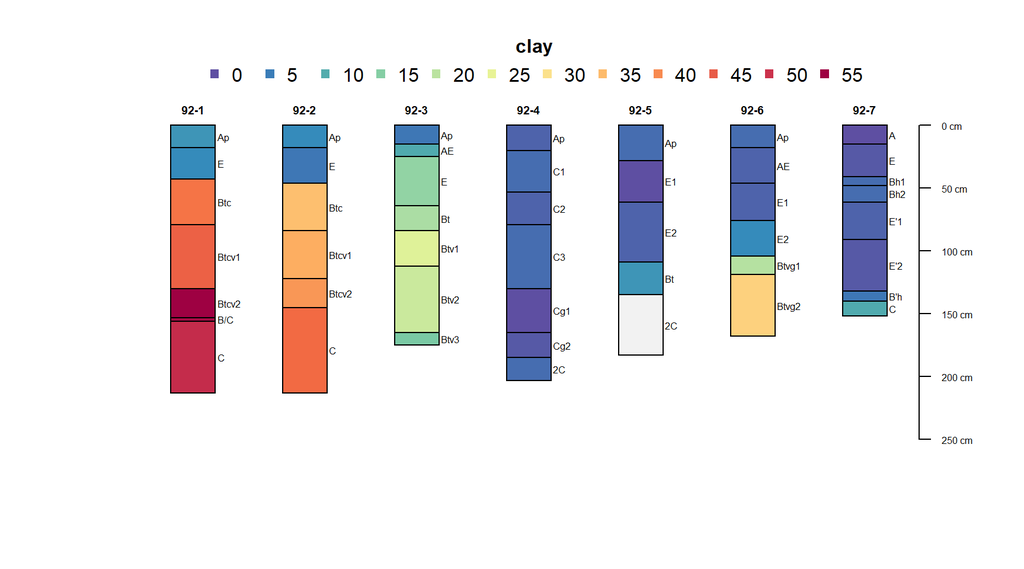

```r
plot(jacobs2000, color = "clay")
```

Many soil properties may contain missing values, so we need `na.rm = TRUE`.

> aggregate(jacobs2000[[‘clay’]], by = list(genhz3 = jacobs2000$genhz4), quantile) Error in quantile.default(X[[i]], …) : missing values and NaN’s not allowed if ‘na.rm’ is FALSE

```r
aggregate(jacobs2000[['clay']], by = list(genhz4 = jacobs2000$genhz4), quantile, na.rm = TRUE)
```

```
##   genhz4  x.0% x.25% x.50% x.75% x.100%
## 1      A  0.00  2.50  3.00  5.00   7.00
## 2      B  7.00 14.50 24.50 33.75  39.00
## 3      C  2.00  3.00  6.00 41.75  50.00
## 4      E  0.00  1.75  2.00  6.00  15.00
## 5     Bh  3.00  3.00  3.00  3.50   4.00
## 6      g  0.00  0.25  0.50  0.75   1.00
## 7      v 13.00 20.00 30.00 36.00  51.00
```

Seems like range on the `C` group is wide. The horizon designation does not capture all properties, so we may be reaching the limits of what we can do with REGEX in this small data set.

### Beyond `quantile()`

We want to consider quantiles carefully along side the number and *quality* of observations. Especially with very small data sets.

Define a “helper” function `my.quantile()` that gives us more than the default `stats::quantile()` method.

```r
#' My Special Quantile Function
#'
#' @description Calculates the `quantile()` values at `prob` and concatenates number of observations `"n"`
#'
#' @param x a numeric vector
#' @param na.rm remove `NA`? default `TRUE` (opposite of `quantile()`)
#' @param prob probability levels; default: `c(0,0.05,0.1,0.25,0.5,0.75,0.9,0.95,1)`
#' @param colnames column names for result; default e.g. `Q50` for `0.5` level.
#' @param ... additional arguments to `quantile()`
#'
#' @return A named numeric vector of the specified quantiles, plus the length of the vector `x` (named `"n"`)
my.quantile <- function(x,
                        na.rm = TRUE,
                        prob = c(0, 0.05, 0.1, 0.25, 0.5, 0.75, 0.9, 0.95, 1),
                        colnames = paste0("Q", prob * 100),
                        ...) {
  res <- round(c(t(quantile(x, prob = prob, na.rm = na.rm, ...)), n = length(x)))
  names(res) <- c(colnames, "n")
  return(res)
}
```

Try aggregating total generalized horizon `thickness` again with `my.quantile()`

```r
aggregate(thbyprof$x, by = list(genhz4 = thbyprof$genhz4), FUN = my.quantile)
```

```
##   genhz4 x.Q0 x.Q5 x.Q10 x.Q25 x.Q50 x.Q75 x.Q90 x.Q95 x.Q100 x.n
## 1      A   15   15    15    16    18    19    23    26     28   7
## 2      B   20   21    22    24    31    36    37    38     38   4
## 3      C   12   19    26    48    60    68   104   116    128   5
## 4      E   25   26    26    33    65    85    92    94     97   6
## 5     Bh   28   28    28    28    28    28    28    28     28   1
## 6      g   55   55    55    55    55    55    55    55     55   1
## 7      v   61   61    62    63    69    78    86    88     91   4
```

And clay contents again

```r
aggregate(jacobs2000[['clay']], by = list(genhz4 = jacobs2000$genhz4), my.quantile)
```

```
##   genhz4 x.Q0 x.Q5 x.Q10 x.Q25 x.Q50 x.Q75 x.Q90 x.Q95 x.Q100 x.n
## 1      A    0    1     1     2     3     5     6     7      7   7
## 2      B    7    8    10    14    24    34    37    38     39   4
## 3      C    2    2     3     3     6    42    48    49     50   9
## 4      E    0    1     1     2     2     6     9    12     15  12
## 5     Bh    3    3     3     3     3     4     4     4      4   3
## 6      g    0    0     0     0     0     1     1     1      1   2
## 7      v   13   15    17    20    30    36    43    47     51   9
```

These quantiles are comparable to thickness ranges reported across multiple sub-horizons in an Official Series Description Typical Pedon, or clay content for horizons reported in the Range in Characteristics section.